# Practica 1

Murillo Alba Josué Iván

Febrero 2025

```r
library(dplyr)
```

1. Realiza una gráfica con los primeros 10 valores de las ecuaciones de diferencias.
2. Realiza otra gráfica, ahora con los primeros 100 valores.
3. Resuelve las ecuaciones en diferencias y verifica que coincida la estabilidad dinámica de las soluciones con la gráficas realizadas. verifica que coincida también el punto de equilibrio si es el caso.
4. Realiza una gráfica con los primeros 10 valores de las soluciones de las ecuaciones de diferencias.

# A

La ecuación es:

$$X_t = -X_{t-1} + 4$$

Con la condición inicial:

$$X_1 = 1$$

## 1

```r
n <- 10
X <- numeric(n)
X[1] <- 1

for(t in 2:n){
  X[t] <- -X[t-1] + 4
}

X[10]
```

```
## [1] 3
```

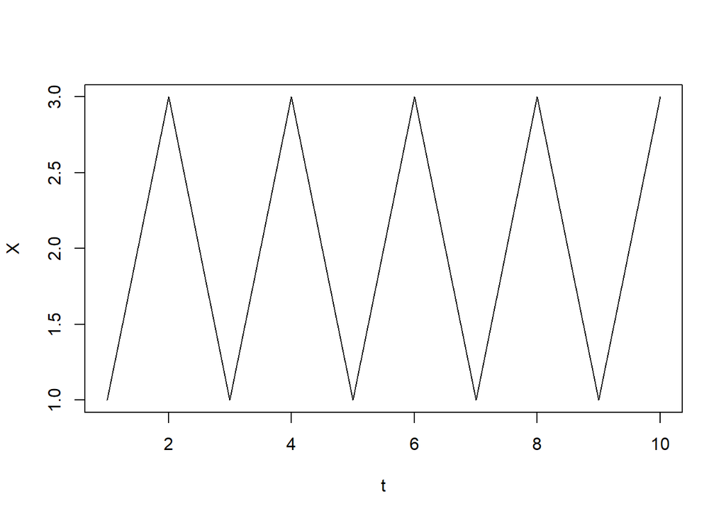

```r
plot(X, type = 'l', xlab = "t")
```

## 2

```r
n <- 100
X <- numeric(n)
X[1] <- 1

for(t in 2:n)
  X[t] <- -X[t-1]+4

X
```

```
##   [1] 1 3 1 3 1 3 1 3 1 3 1 3 1 3 1 3 1 3 1 3 1 3 1 3 1 3 1 3 1 3 1 3 1 3 1 3 1
##  [38] 3 1 3 1 3 1 3 1 3 1 3 1 3 1 3 1 3 1 3 1 3 1 3 1 3 1 3 1 3 1 3 1 3 1 3 1 3
##  [75] 1 3 1 3 1 3 1 3 1 3 1 3 1 3 1 3 1 3 1 3 1 3 1 3 1 3
```

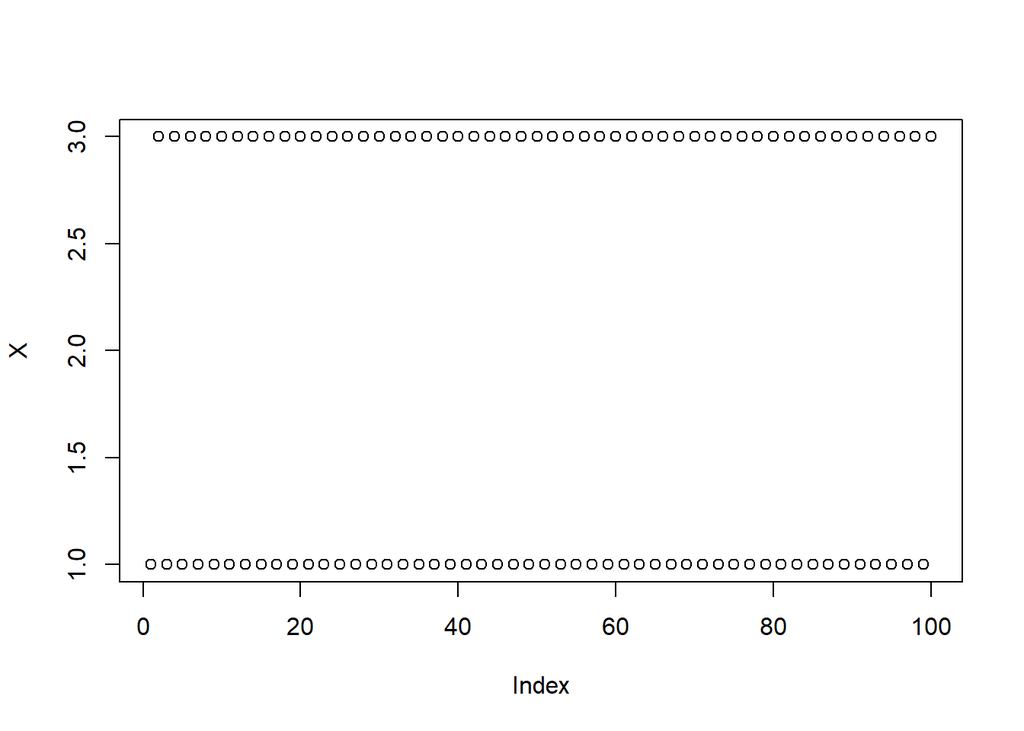

```r
plot(X)
```

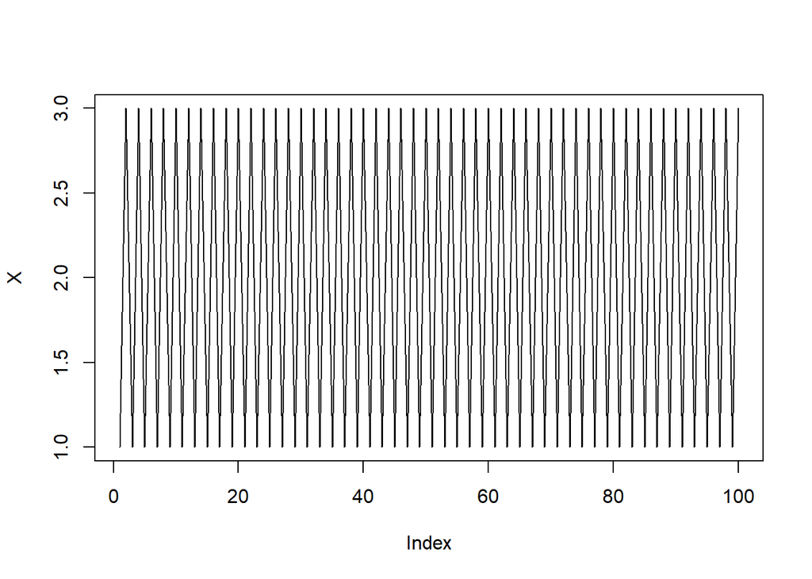

```r
plot(X, type = 'l')
```

## 3

Verificación de estabilidad dinámica y punto de equilibrio Estabilidad dinámica: ciclica alternante

## 4

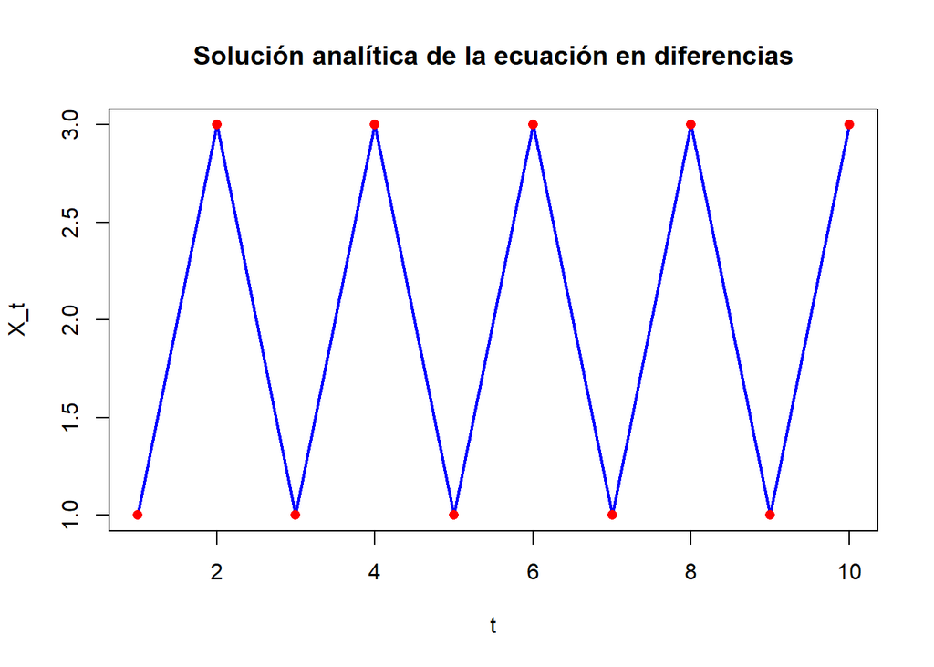

```r
n <- 10
y <- numeric(n)

for (t in 1:n)
  y[t] <- 1*(-1)^t + 2

plot(y, type="l", col="blue", lwd=2, xlab="t", ylab="X_t", main="Solución analítica de la ecuación en diferencias")
points(y, pch=16, col="red")
```

# B

La ecuación es:

$$X_t = -\frac{4}{5} X_{t-1} + 2$$

Con la condición inicial:

$$X_1 = 1$$

## 1

```r
n <- 10
X <- numeric(n)
X[1] <- 1

for(t in 2:n){
  X[t] <- -(4/5)*X[t-1] + 2
}

X[10]
```

```
## [1] 1.126024
```

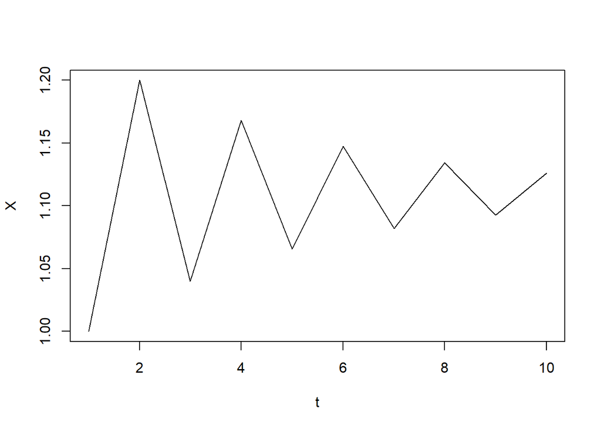

```r
plot(X, type = 'l', xlab = "t")
```

## 2

```r
n <- 100
X <- numeric(n)
X[1] <- 1

for(t in 2:n)
  X[t] <- -(4/5)*X[t-1] + 2

X
```

```
##   [1] 1.000000 1.200000 1.040000 1.168000 1.065600 1.147520 1.081984 1.134413
##   [9] 1.092470 1.126024 1.099181 1.120655 1.103476 1.117220 1.106224 1.115020
##  [17] 1.107984 1.113613 1.109110 1.112712 1.109830 1.112136 1.110291 1.111767
##  [25] 1.110586 1.111531 1.110775 1.111380 1.110896 1.111283 1.110974 1.111221
##  [33] 1.111023 1.111182 1.111055 1.111156 1.111075 1.111140 1.111088 1.111130
##  [41] 1.111096 1.111123 1.111102 1.111119 1.111105 1.111116 1.111107 1.111114
##  [49] 1.111109 1.111113 1.111110 1.111112 1.111110 1.111112 1.111110 1.111112
##  [57] 1.111111 1.111111 1.111111 1.111111 1.111111 1.111111 1.111111 1.111111
##  [65] 1.111111 1.111111 1.111111 1.111111 1.111111 1.111111 1.111111 1.111111
##  [73] 1.111111 1.111111 1.111111 1.111111 1.111111 1.111111 1.111111 1.111111
##  [81] 1.111111 1.111111 1.111111 1.111111 1.111111 1.111111 1.111111 1.111111
##  [89] 1.111111 1.111111 1.111111 1.111111 1.111111 1.111111 1.111111 1.111111
##  [97] 1.111111 1.111111 1.111111 1.111111
```

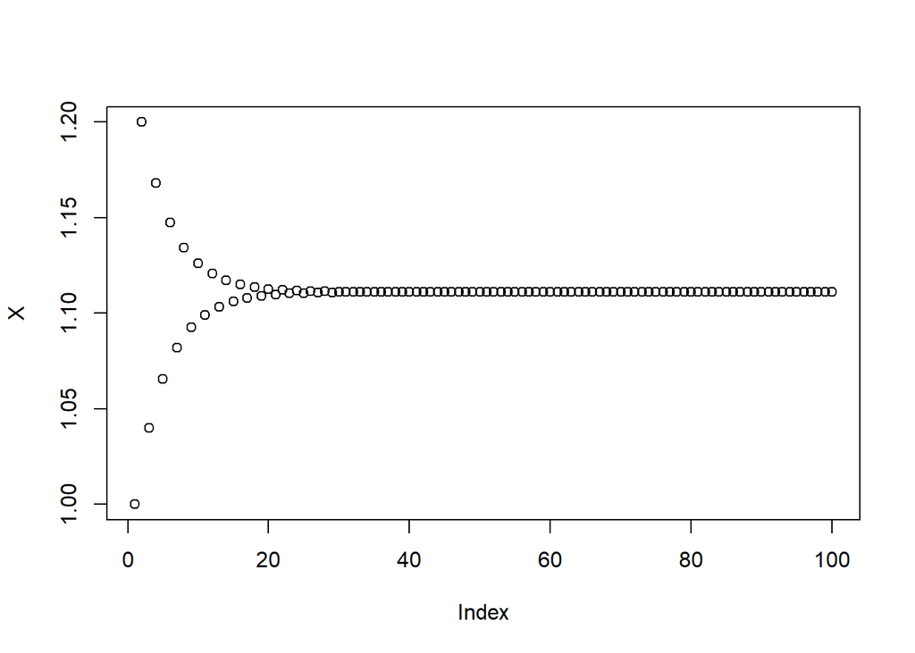

```r
plot(X)
```

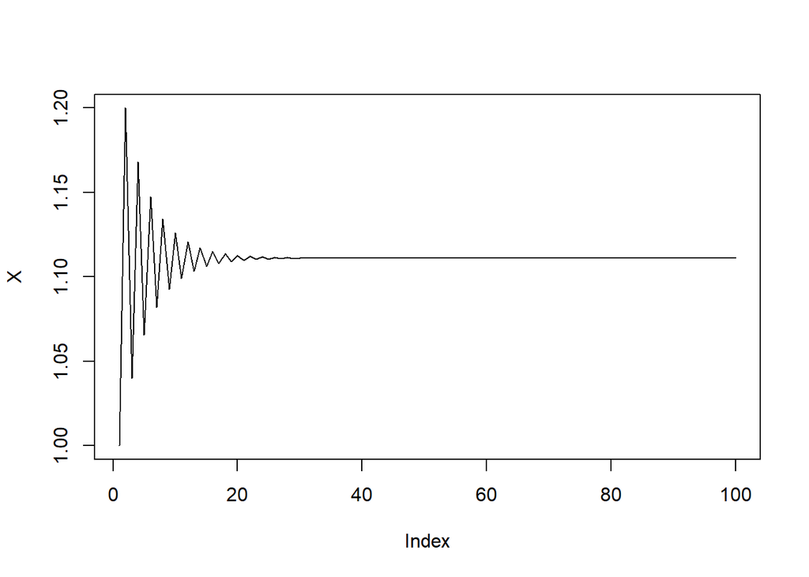

```r
plot(X, type = 'l')
```

## 3

Verificación de estabilidad dinámica y punto de equilibrio Estabilidad dinámica: alternante convergente

En la solución lambda esta entre -1 y 0 por lo que la funcion tendera a ir a rotar del punto de equilibrio que es 10/9 a +- 5/36 alternando hasta converger o aproximarce a este punto de equililbrio es decir xt tendera a 10/9 cuanto t tienda a infinito

## 4

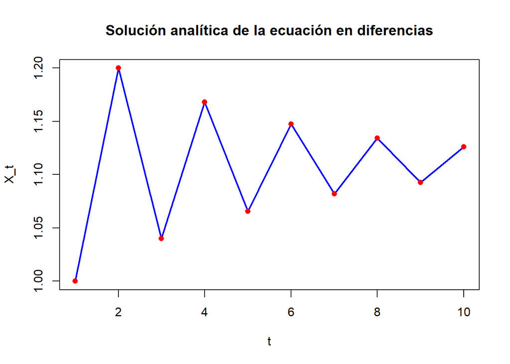

```r
n <- 10
y <- numeric(n)

for (t in 1:n)
  y[t] <- (5/36)*(-4/5)^t + (10/9)

plot(y, type="l", col="blue", lwd=2, xlab="t", ylab="X_t", main="Solución analítica de la ecuación en diferencias")
points(y, pch=16, col="red")
```

# C

La ecuación es:

$$X_t = 1.1 X_{t-1} + 1$$

Con la condición inicial:

## 1

```r
n <- 10
X <- numeric(n)
X[1] <- 1

for(t in 2:n){
  X[t] <- 1.1*X[t-1] + 1
}

X[10]
```

```
## [1] 15.93742
```

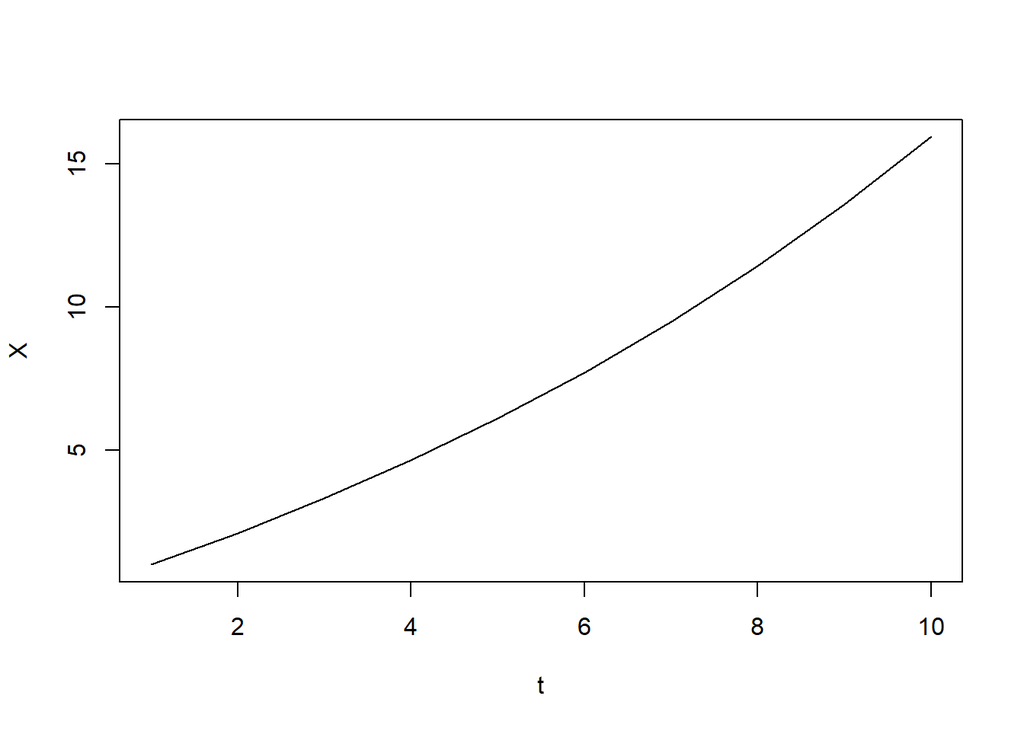

```r
plot(X, type = 'l', xlab = "t")
```

## 2

```r
n <- 100
X <- numeric(n)
X[1] <- 1

for(t in 2:n)
  X[t] <- 1.1*X[t-1] + 1

X
```

```
##   [1] 1.000000e+00 2.100000e+00 3.310000e+00 4.641000e+00 6.105100e+00
##   [6] 7.715610e+00 9.487171e+00 1.143589e+01 1.357948e+01 1.593742e+01
##  [11] 1.853117e+01 2.138428e+01 2.452271e+01 2.797498e+01 3.177248e+01
##  [16] 3.594973e+01 4.054470e+01 4.559917e+01 5.115909e+01 5.727500e+01
##  [21] 6.400250e+01 7.140275e+01 7.954302e+01 8.849733e+01 9.834706e+01
##  [26] 1.091818e+02 1.210999e+02 1.342099e+02 1.486309e+02 1.644940e+02
##  [31] 1.819434e+02 2.011378e+02 2.222515e+02 2.454767e+02 2.710244e+02
##  [36] 2.991268e+02 3.300395e+02 3.640434e+02 4.014478e+02 4.425926e+02
##  [41] 4.878518e+02 5.376370e+02 5.924007e+02 6.526408e+02 7.189048e+02
##  [46] 7.917953e+02 8.719749e+02 9.601723e+02 1.057190e+03 1.163909e+03
##  [51] 1.281299e+03 1.410429e+03 1.552472e+03 1.708719e+03 1.880591e+03
##  [56] 2.069651e+03 2.277616e+03 2.506377e+03 2.758015e+03 3.034816e+03
##  [61] 3.339298e+03 3.674228e+03 4.042651e+03 4.447916e+03 4.893707e+03
##  [66] 5.384078e+03 5.923486e+03 6.516834e+03 7.169518e+03 7.887470e+03
##  [71] 8.677217e+03 9.545938e+03 1.050153e+04 1.155269e+04 1.270895e+04
##  [76] 1.398085e+04 1.537993e+04 1.691893e+04 1.861182e+04 2.047400e+04
##  [81] 2.252240e+04 2.477564e+04 2.725421e+04 2.998063e+04 3.297969e+04
##  [86] 3.627866e+04 3.990753e+04 4.389928e+04 4.829021e+04 5.312023e+04
##  [91] 5.843325e+04 6.427757e+04 7.070633e+04 7.777796e+04 8.555676e+04
##  [96] 9.411344e+04 1.035258e+05 1.138794e+05 1.252683e+05 1.377961e+05
```

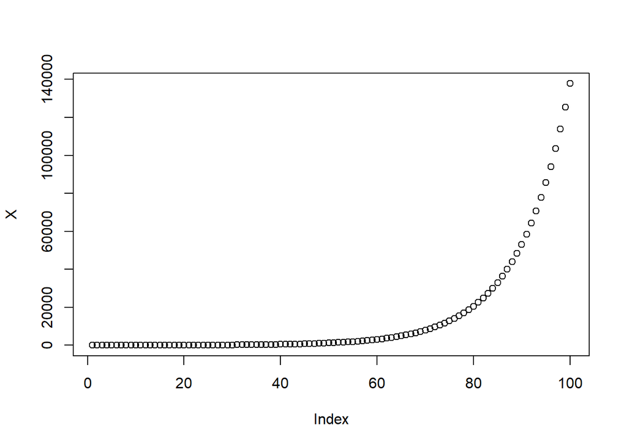

```r
plot(X)
```

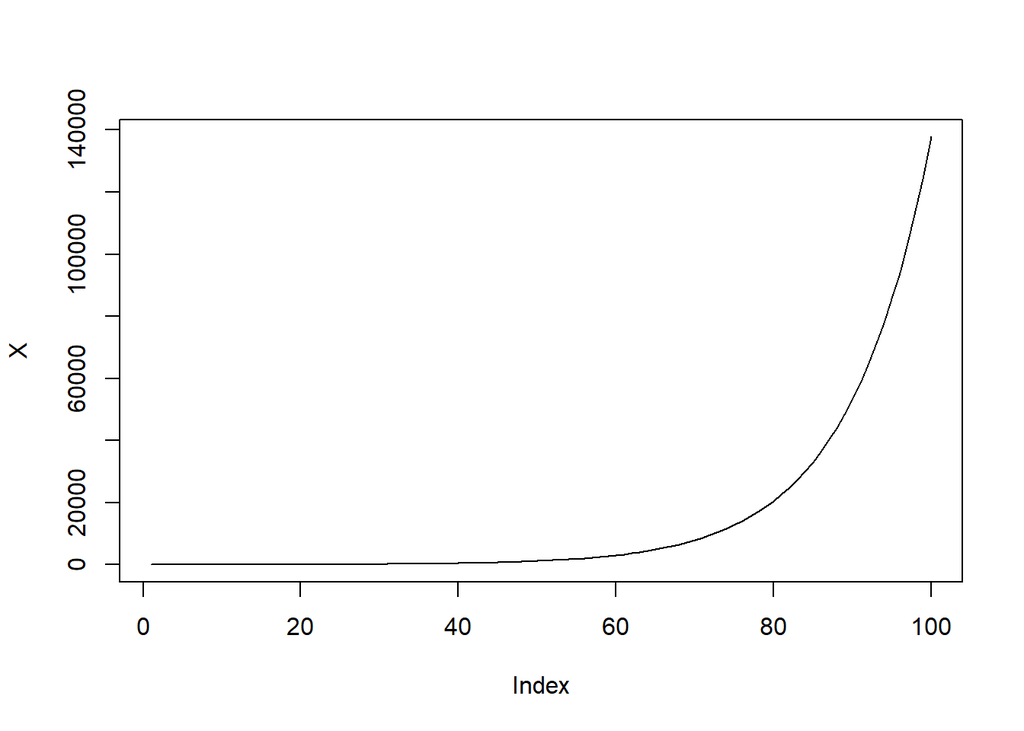

```r
plot(X, type = 'l')
```

## 3

Verificación de estabilidad dinámica y punto de equilibrio Estabilidad dinámica: Explosiva divergente

En la solución lambda > 1 por lo que cuando xt -> inf ‘t’ -> inf partiendo desde -10 o alejandose de este

## 4

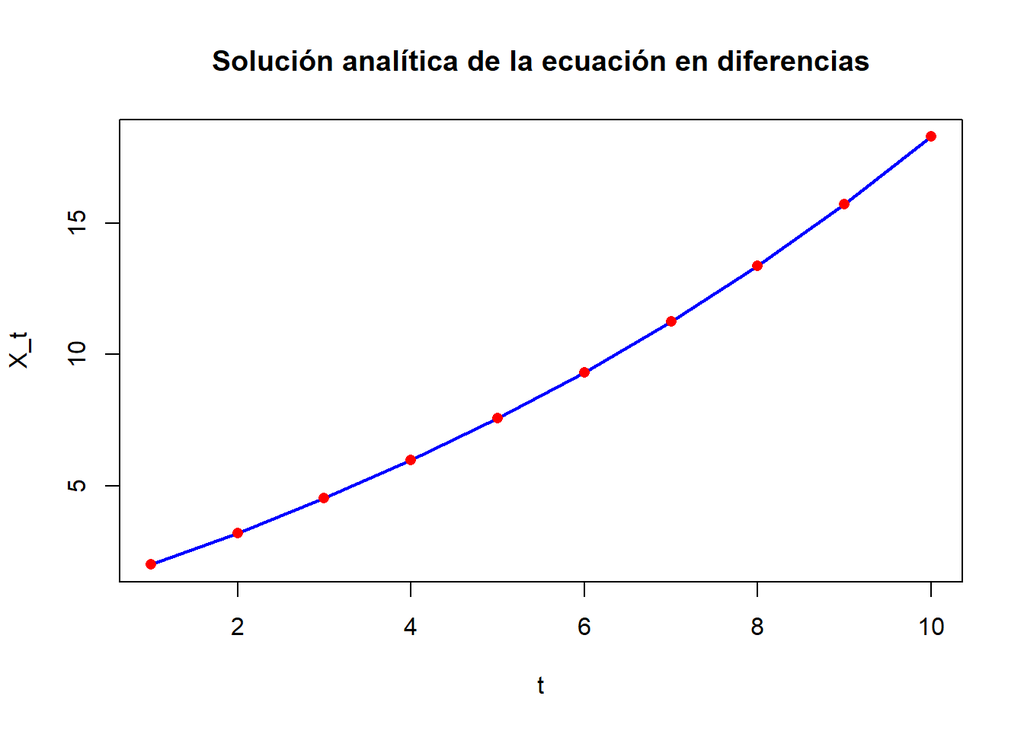

```r
n <- 10
y <- numeric(n)

for (t in 1:n)
  y[t] <- 10.91*(1.1)^t-10

plot(y, type="l", col="blue", lwd=2, xlab="t", ylab="X_t", main="Solución analítica de la ecuación en diferencias")
points(y, pch=16, col="red")
```

# D

La ecuación es:

$$X_t = -\frac{7}{3} X_{t-1} - \frac{2}{3} X_{t-2}$$

Con las condiciones iniciales:

## 1

```r
n <- 10
X <- numeric(n)
X[1] <- 1

for(t in 3:n){
  X[t] <- -(7/3)*X[t-1] - (2/3)*X[t-2]
}

X[10]
```

```
## [1] 102.3999
```

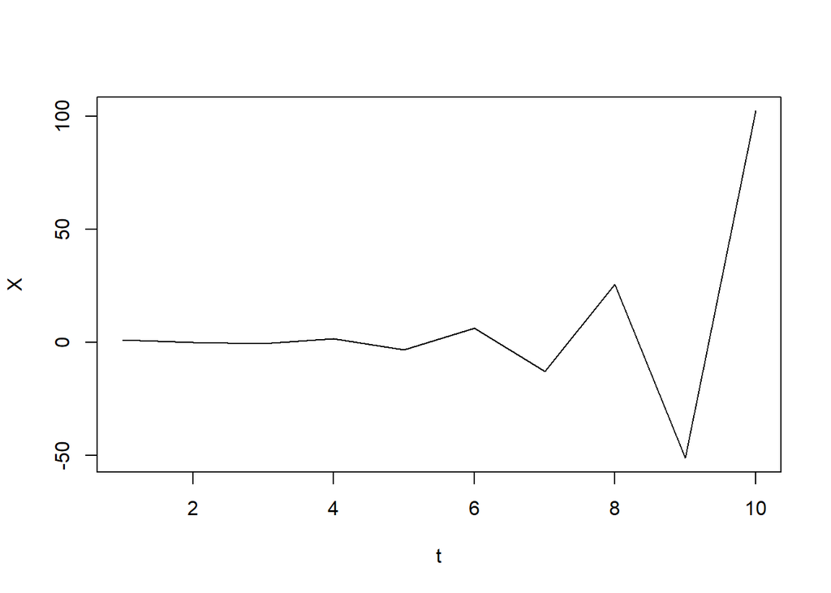

```r
plot(X, type = 'l', xlab = "t")
```

## 2

```r
n <- 100
X <- numeric(n)
X[1] <- 1

for(t in 3:n)
  X[t] <--(7/3)*X[t-1] - (2/3)*X[t-2]

X
```

```
##   [1]  1.000000e+00  0.000000e+00 -6.666667e-01  1.555556e+00 -3.185185e+00
##   [6]  6.395062e+00 -1.279835e+01  2.559945e+01 -5.119982e+01  1.023999e+02
##  [11] -2.048000e+02  4.096000e+02 -8.192000e+02  1.638400e+03 -3.276800e+03
##  [16]  6.553600e+03 -1.310720e+04  2.621440e+04 -5.242880e+04  1.048576e+05
##  [21] -2.097152e+05  4.194304e+05 -8.388608e+05  1.677722e+06 -3.355443e+06
##  [26]  6.710886e+06 -1.342177e+07  2.684355e+07 -5.368709e+07  1.073742e+08
##  [31] -2.147484e+08  4.294967e+08 -8.589935e+08  1.717987e+09 -3.435974e+09
##  [36]  6.871948e+09 -1.374390e+10  2.748779e+10 -5.497558e+10  1.099512e+11
##  [41] -2.199023e+11  4.398047e+11 -8.796093e+11  1.759219e+12 -3.518437e+12
##  [46]  7.036874e+12 -1.407375e+13  2.814750e+13 -5.629500e+13  1.125900e+14
##  [51] -2.251800e+14  4.503600e+14 -9.007199e+14  1.801440e+15 -3.602880e+15
##  [56]  7.205759e+15 -1.441152e+16  2.882304e+16 -5.764608e+16  1.152922e+17
##  [61] -2.305843e+17  4.611686e+17 -9.223372e+17  1.844674e+18 -3.689349e+18
##  [66]  7.378698e+18 -1.475740e+19  2.951479e+19 -5.902958e+19  1.180592e+20
##  [71] -2.361183e+20  4.722366e+20 -9.444733e+20  1.888947e+21 -3.777893e+21
##  [76]  7.555786e+21 -1.511157e+22  3.022315e+22 -6.044629e+22  1.208926e+23
##  [81] -2.417852e+23  4.835703e+23 -9.671407e+23  1.934281e+24 -3.868563e+24
##  [86]  7.737125e+24 -1.547425e+25  3.094850e+25 -6.189700e+25  1.237940e+26
##  [91] -2.475880e+26  4.951760e+26 -9.903520e+26  1.980704e+27 -3.961408e+27
##  [96]  7.922816e+27 -1.584563e+28  3.169127e+28 -6.338253e+28  1.267651e+29
```

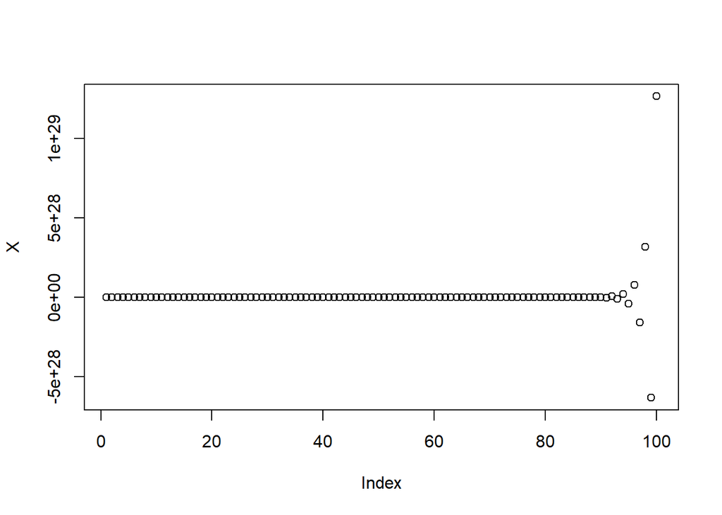

```r
plot(X)
```

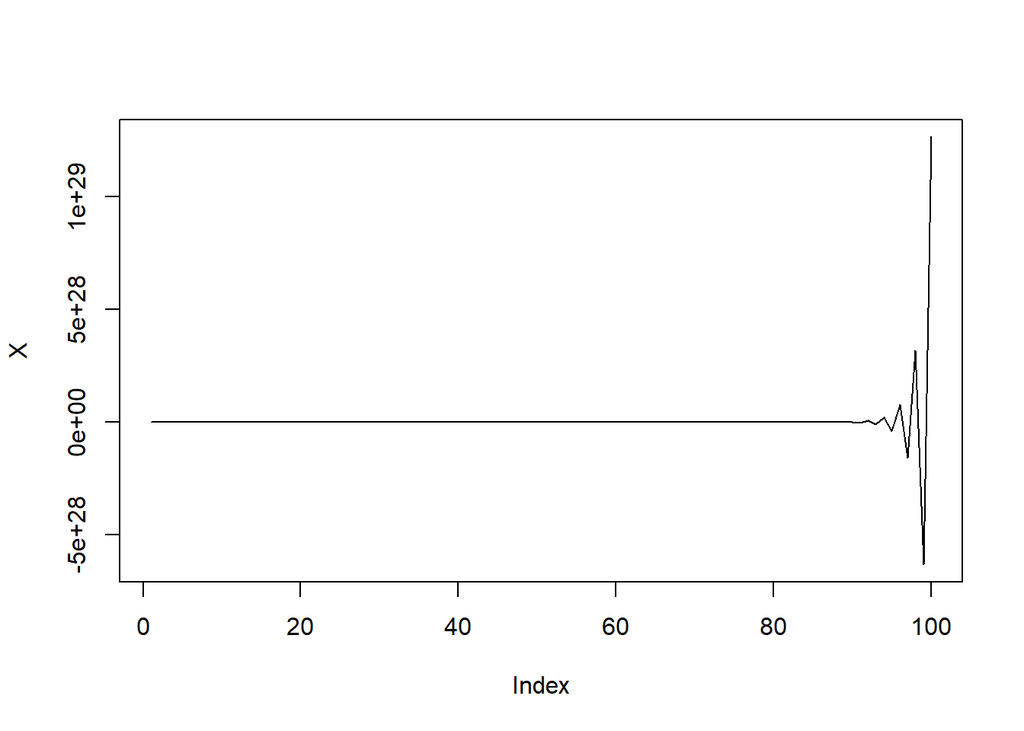

```r
plot(X, type = 'l')
```

## 3

Verificación de estabilidad dinámica y punto de equilibrio Estabilidad dinámica: divergente y alternante a largo plazo

tenemos dos labda -1<lmda1<0 alternante convergente y lmda<-1 divergente, se observa que primero converge hacia cero pero despues tiende a tener un comportamiento explosivo incrementando hacia infinito

## 4

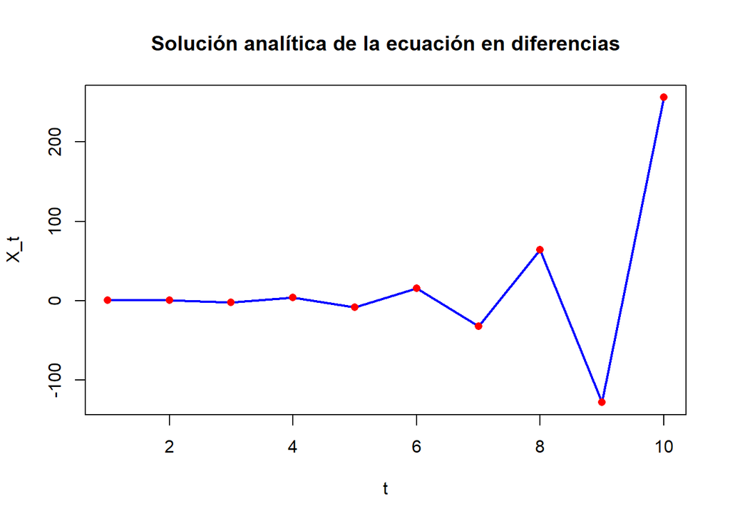

```r
n <- 10
y <- numeric(n)

for (t in 1:n)
  y[t] <- (108/432)*(-2)^t+(-18/5)*(-1/3)^t

plot(y, type="l", col="blue", lwd=2, xlab="t", ylab="X_t", main="Solución analítica de la ecuación en diferencias")
points(y, pch=16, col="red")
```

# E

La ecuación es:

$$X_t = \frac{5}{6} X_{t-1} + \frac{1}{6} X_{t-2} + 2$$

Con la condición inicial:

## 1

```r
n <- 10
X <- numeric(n)
X[1] <- 1

for(t in 3:n){
  X[t] <- (5/6)*X[t-1] +  (1/6)*X[t-2] + 2
}

X[10]
```

```
## [1] 14.10204
```

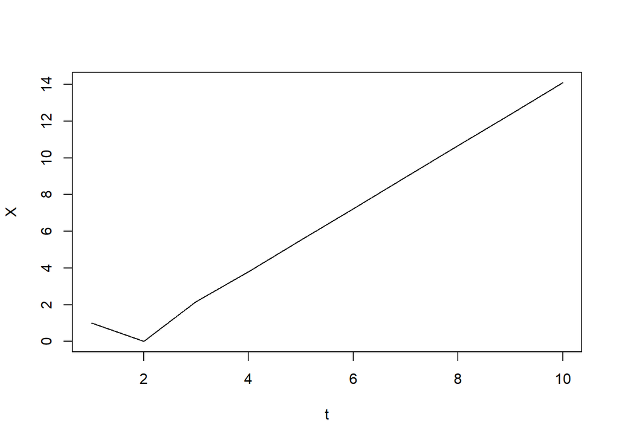

```r
plot(X, type = 'l', xlab = "t")
```

## 2

```r
n <- 100
X <- numeric(n)
X[1] <- 1

for(t in 3:n)
  X[t] <- (5/6)*X[t-1] +  (1/6)*X[t-2] + 2

X
```

```
##   [1]   1.000000   0.000000   2.166667   3.805556   5.532407   7.244599
##   [7]   8.959234  10.673461  12.387756  14.102041  15.816327  17.530612
##  [13]  19.244898  20.959184  22.673469  24.387755  26.102041  27.816327
##  [19]  29.530612  31.244898  32.959184  34.673469  36.387755  38.102041
##  [25]  39.816327  41.530612  43.244898  44.959184  46.673469  48.387755
##  [31]  50.102041  51.816327  53.530612  55.244898  56.959184  58.673469
##  [37]  60.387755  62.102041  63.816327  65.530612  67.244898  68.959184
##  [43]  70.673469  72.387755  74.102041  75.816327  77.530612  79.244898
##  [49]  80.959184  82.673469  84.387755  86.102041  87.816327  89.530612
##  [55]  91.244898  92.959184  94.673469  96.387755  98.102041  99.816327
##  [61] 101.530612 103.244898 104.959184 106.673469 108.387755 110.102041
##  [67] 111.816327 113.530612 115.244898 116.959184 118.673469 120.387755
##  [73] 122.102041 123.816327 125.530612 127.244898 128.959184 130.673469
##  [79] 132.387755 134.102041 135.816327 137.530612 139.244898 140.959184
##  [85] 142.673469 144.387755 146.102041 147.816327 149.530612 151.244898
##  [91] 152.959184 154.673469 156.387755 158.102041 159.816327 161.530612
##  [97] 163.244898 164.959184 166.673469 168.387755
```

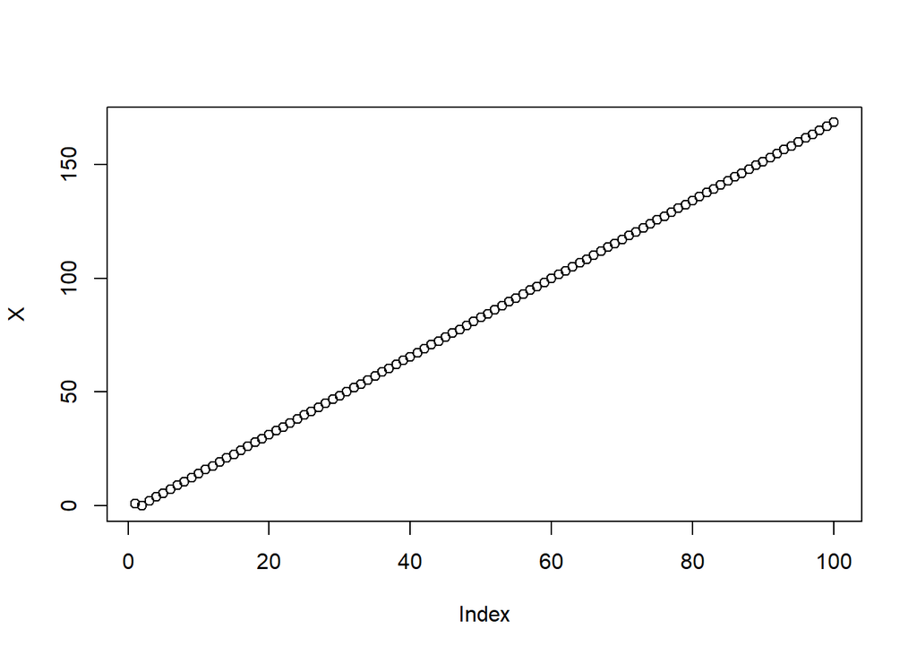

```r
plot(X)
```

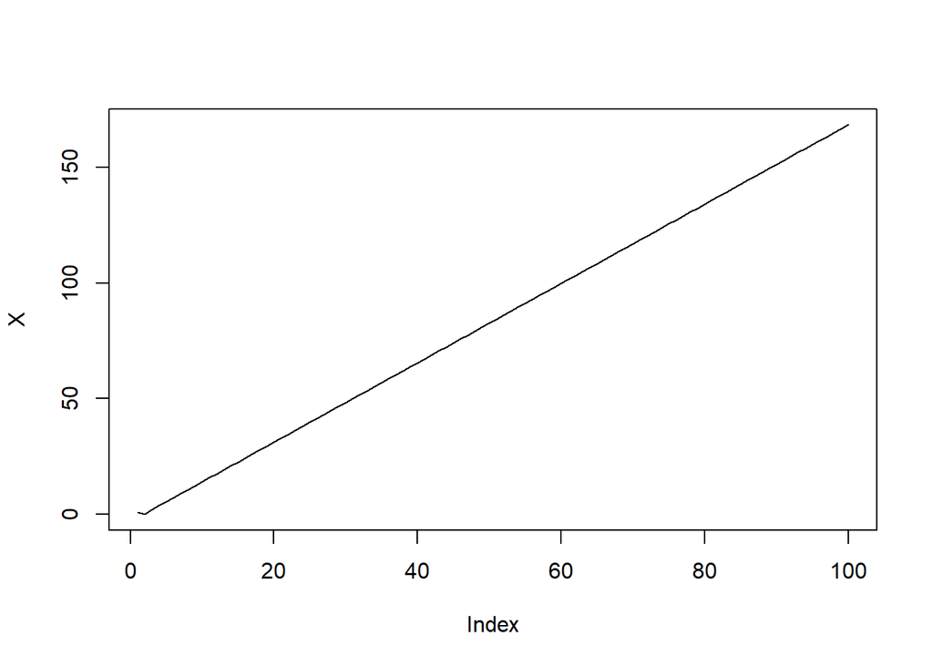

```r
plot(X, type = 'l')
```

## 3

Verificación de estabilidad dinámica y punto de equilibrio Estabilidad dinámica: divergente

Divergencia: El término 12/7𝑡 crece sin límite a medida que 𝑡aumenta, lo que causa que la serie en conjunto sea divergente.

Alternancia: El segundo término alterna en signo debido a la base negativa (−1/6), mientras que el primer y tercer término no alternan.

En resumen, la serie es divergente debido al crecimiento lineal del tercer término y contiene un término que alterna en signo.

## 4

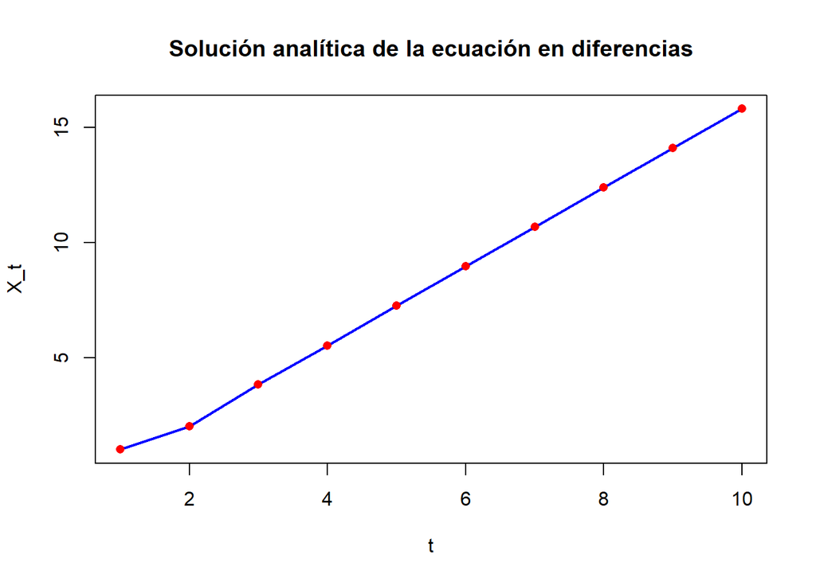

```r
n <- 10
y <- numeric(n)

for (t in 1:n)
  y[t] <- (-65/49)*(1)^t+(-180/49)*(-1/6)^t+(12/7)*t

plot(y, type="l", col="blue", lwd=2, xlab="t", ylab="X_t", main="Solución analítica de la ecuación en diferencias")
points(y, pch=16, col="red")
```

## Comportamiento de la serie según el valor de λ

Si $0 < \lambda < 1$:

- La serie es **convergente y decreciente**.
- A medida que $t$ aumenta, $\lambda^t$ tiende a 0.

Si $\lambda > 1$:

- La serie es **divergente**.
- A medida que $t$ aumenta, $\lambda^t$ tiende a infinito.

Si $\lambda = 1$:

- La serie es **constante**.
- $\lambda^t = 1$ para todos los valores de $t$.

Si $-1 < \lambda < 0$:

- La serie es **alternante y decreciente**.
- A medida que $t$ aumenta, $\lambda^t$ tiende a 0, alternando en signo.

Si $\lambda < -1$:

- La serie es **divergente y alternante**.
- A medida que $t$ aumenta, $\lambda^t$ crece en magnitud hacia infinito, alternando en signo.

Si $\lambda = -1$: